# Visualizing Taxi Availability in Singapore

Ng Wei Xuan

5/26/2020

This project aims to visualize the availability of Taxis in Singapore. Consumers in Singapore often experience a lack of taxis when they urgently need one. Thus, this project aims to guide consumers and help them plan their trips by allowing them to see the taxi availability at the timings they want.

The data is sourced from the Taxi Availability API from data.gov (https://data.gov.sg/dataset/taxi-availability)

First, we need to load the required packages

```r
library(jsonlite)
library(ggmap)
library('revgeo')
library(ggplot2)
library(tidyverse)
library(formattable)
library(leaflet)
```

Next, we need to find out how we can extract the data from the API. We will need to look at the query to get the data.

Example date_time query :

2020-01-02T13:11:05 means year 2020, 2nd Jan, 13:11pm,05 secs

URL: “https://api.data.gov.sg/v1/transport/taxi-availability?date_time=2020-01-02T13%3A11%3A05”

Now, lets explore the data, we see that it is in a tree structure, like a XML structure.

```r
url <- "https://api.data.gov.sg/v1/transport/taxi-availability?date_time=2020-01-02T11%3A11%3A05"
data <- fromJSON(url)
str(data)
```

```
## List of 3
##  $ type    : chr "FeatureCollection"
##  $ crs     :List of 2
##   ..$ type      : chr "link"
##   ..$ properties:List of 2
##   .. ..$ href: chr "http://spatialreference.org/ref/epsg/4326/ogcwkt/"
##   .. ..$ type: chr "ogcwkt"
##  $ features:'data.frame':    1 obs. of  3 variables:
##   ..$ type      : chr "Feature"
##   ..$ geometry  :'data.frame':   1 obs. of  2 variables:
##   .. ..$ type       : chr "MultiPoint"
##   .. ..$ coordinates:List of 1
##   .. .. ..$ : num [1:4900, 1:2] 104 104 104 104 104 ...
##   ..$ properties:'data.frame':   1 obs. of  3 variables:
##   .. ..$ timestamp : chr "2020-01-02T11:10:55+08:00"
##   .. ..$ taxi_count: int 4900
##   .. ..$ api_info  :'data.frame':    1 obs. of  1 variable:
##   .. .. ..$ status: chr "healthy"
```

This shows the total taxi count at the date_time

```r
#This is where the date_time query is applied

url <- "https://api.data.gov.sg/v1/transport/taxi-availability?date_time=2020-01-02T11%3A11%3A05"
data <- fromJSON(url)
taxi_count <- as.data.frame(data$features$properties$taxi_count)
taxi_count
```

```
##   data$features$properties$taxi_count
## 1                                4900
```

This shows location coordinates of all taxis available for hire. Does not include “Hired” or “Busy”

We are interested in this segment in particular as it will give us the location of available taxis at each time slot selected.

```r
coordinates <- as.data.frame(data$features$geometry$coordinates)

head(coordinates)
```

```
##         X1       X2
## 1 103.6230 1.289210
## 2 103.6231 1.289045
## 3 103.6232 1.289220
## 4 103.6261 1.288950
## 5 103.6266 1.295440
## 6 103.6285 1.284880
```

Let’s create a function to get a dataframe of coordinates over a range of dates and times.

```r
get_coordinates <- function (date1,date2,hour1,hour2) {

  #initialise an empty df for us to append to for every record with different time
  empty_df <- data.frame(X1=NA,X2=NA,time=NA,Date=NA)

  #Initialise base urls
  url1 <- "https://api.data.gov.sg/v1/transport/taxi-availability?date_time="
  url2 <- "%3A"
  url3 <- "%3A"
  #Format the variables accordingly
  day1 <- as.numeric(format(as.Date(date1,format="%Y-%m-%d"), format = "%d"))
  day2 <- as.numeric(format(as.Date(date2,format="%Y-%m-%d"), format = "%d"))
  year1 <- as.numeric(format(as.Date(date1,format="%Y-%m-%d"), format = "%Y"))
  year2 <- as.numeric(format(as.Date(date2,format="%Y-%m-%d"), format = "%Y"))
  month1 <- as.numeric(format(as.Date(date1,format="%Y-%m-%d"), format = "%m"))
  month2 <- as.numeric(format(as.Date(date2,format="%Y-%m-%d"), format = "%m"))
  hour1 <- as.numeric(hour1)
  hour2 <- as.numeric(hour2)

  #Loop through each year,month,day and hour as declared in the function
  for (year in year1:year2) {
    for (month in month1:month2) {
      for (day in day1:day2) {
        for (hour in hour1:hour2) {


          #Ensure that day, month and hour are 2 digits because the URL only accepts it if they are in the proper format
          day <- formatC(day, digits = 2, width = 2, flag=0)
          month <- formatC(month, digits = 2, width = 2, flag=0)
          hour <- formatC(hour, digits = 2, width = 2, flag=0)
          #get URL
          url <- paste(url1, year,"-", month, "-",day, "T", hour, url2, "00", url3, "00", sep="")
          #extract data from url
          data <- fromJSON(url)

          coordinates <- as.data.frame(data$features$geometry$coordinates)
          time_stamp_date <- paste(year, "/",month,'/',day,sep='')

          time_stamp_time <- paste(hour,': 00',sep='')
          coordinates$time <- time_stamp_time
          coordinates$Date <- time_stamp_date
          empty_df <- rbind(empty_df,coordinates)
          empty_df$Date <- as.Date(time_stamp_date,format="%Y/%m/%d")


        }
      }
    }
  }


  #We don't want the row of NA that was declared at the 1st column
  return(na.omit(empty_df))
}
```

Let’s presume it is the 10th of January 2020 and we are planning to take a taxi at around 14:00 hours. We want to know whether taxis will be availabe at this time.

To do so, we look at the taxi availability at 14:00 hours, over the past 2 days from 8 Jan 2020 to 9 Jan 2020 so that we can estimate the taxi availability for our trip on 10 Jan 2020 at around 14:00 hours.

```r
df <- get_coordinates("2020-01-08","2020-01-09",14,14)

tail(df)
```

```
##            X1       X2   time       Date
## 7772 103.9906 1.360800 14: 00 2020-01-09
## 7773 103.9906 1.357460 14: 00 2020-01-09
## 7774 103.9906 1.357623 14: 00 2020-01-09
## 7775 103.9955 1.371740 14: 00 2020-01-09
## 7776 103.9970 1.389530 14: 00 2020-01-09
## 7777 104.0014 1.382460 14: 00 2020-01-09
```

```r
#Check number of records
nrow(df)
```

```
## [1] 7776
```

So now we have a dataframe consisting of : 1) Coordinates of the taxi 2) Date 3) Time However, the coordinates by itself does not make much sense. We need to know the district corresponding to the coordinates in order for it to make sense. For instance, we are only interested in the taxi availability around our location and a X1 coordinate of 103 will not help us determine this.

Thus, we will extract the district names corresponding to the coordinates. We will use the revgeocode function from ggmap.

An example below shows that revgeocode function gives us various information corresponding to the coordinate.

We are interested in the one that contains “Tuas, Singapore”. It seems that this occurs before the first record with “Singapore”.

```r
length <- length(revgeocode(c(103.6314  ,1.307750),output="all")$results)
print(length)
```

```
## [1] 7
```

```r
for (i in seq(1,length)) {
  print(revgeocode(c(103.6314   ,1.307750),output="all")$results[[i]]$formatted_address)


}
```

```
## [1] "2 Tuas South Street 2, Singapore 637895"
## [1] "2 Tuas South Street 2, Singapore 637895"
## [1] "2 Tuas South Street 2, Singapore"
## [1] "Tuas South Street 2, Singapore"
## [1] "Tuas, Singapore"
## [1] "Singapore"
## [1] "Singapore"
```

Another example of the revgeocode function here.

Again, the district name occurs before the first record with “Singapore”. We are interested in “Tanglin, Singapore”.

Thus, the logic here is to access the record just before the first occurance of “Singapore”. Let’s try.

```r
length <- length(revgeocode(c(103.8294,1.288200),output="all")$results)
print(length)
```

```
## [1] 5
```

```r
for (i in seq(1,length)) {
  print(revgeocode(c(103.8298, 1.318330),output="all")$results[[i]]$formatted_address)


}
```

```
## [1] "355 Bukit Timah Rd, Singapore 259724"
## [1] "357 Bukit Timah Rd, Singapore"
## [1] "48 Ewe Boon Rd, Singapore"
## [1] "Tanglin, Singapore"
## [1] "Singapore"
```

```r
for(i in 1:nrow(df)){

    #Look for the length of each revgeocode attribute for each row in df
    length <- length(revgeocode(c(df$X1[i],df$X2[i]),output="all")$results)

    #Reduce the number of records to loop through
    min_length <- length - 3
    min_length <- max(min_length,1)
    for(j in (min_length):length){

        obj <- (revgeocode(c(df$X1[i],df$X2[i]),output="all")$results[[j]]$formatted_address)

        #If the revgeocode attribute matches "Singapore" exactly, then extract the record before that
        if ((obj)=='Singapore'){
            target_index <- j - 1

            #The district name will be the record before "Singapore" occurs
            district <- (revgeocode(c(df$X1[i],df$X2[i]),output="all")$results[[target_index]]$formatted_address)
            #district <- sub(", Singapore", "", district)
            district <- toupper(district)
            df$District[i] <- district
            break
        }

    }

}
```

```r
head(df,10)
```

```
##          X1       X2   time       Date        District
## 2  103.6208 1.265378 14: 00 2020-01-09 TUAS, SINGAPORE
## 3  103.6238 1.300970 14: 00 2020-01-09 TUAS, SINGAPORE
## 4  103.6256 1.306130 14: 00 2020-01-09 TUAS, SINGAPORE
## 5  103.6260 1.289620 14: 00 2020-01-09 TUAS, SINGAPORE
## 6  103.6264 1.289440 14: 00 2020-01-09 TUAS, SINGAPORE
## 7  103.6272 1.295100 14: 00 2020-01-09 TUAS, SINGAPORE
## 8  103.6287 1.314350 14: 00 2020-01-09 TUAS, SINGAPORE
## 9  103.6328 1.323940 14: 00 2020-01-09 TUAS, SINGAPORE
## 10 103.6346 1.295160 14: 00 2020-01-09 TUAS, SINGAPORE
## 11 103.6350 1.334590 14: 00 2020-01-09 TUAS, SINGAPORE
```

Now, we check if there are any records where the district name has been incorrectly extracted.

We can see a few records where street name has been extracted instead of district names, such as “61 MARINA COASTAL DR, SINGAPORE” which should be categorised as “MARINA COASTAL DR, SINGAPORE” instead.

Also, there are records where district name is categorised as “YISHUN AVE 1, SINGAPORE” instead of “YISHUN, SINGAPORE”.

We will now replace these records with the correct district name.

```r
unique(df$District)
```

```
##  [1] "TUAS, SINGAPORE"                    "PIONEER, SINGAPORE"
##  [3] "WESTERN ISLANDS, SINGAPORE"         "WESTERN WATER CATCHMENT, SINGAPORE"
##  [5] "JURONG WEST, SINGAPORE"             "BOON LAY, SINGAPORE"
##  [7] "JURONG EAST, SINGAPORE"             "TENGAH, SINGAPORE"
##  [9] "CHOA CHU KANG, SINGAPORE"           "TEBAN GARDENS, SINGAPORE"
## [11] "BUKIT BATOK, SINGAPORE"             "PANDAN GARDENS, SINGAPORE"
## [13] "CLEMENTI, SINGAPORE"                "SUNGEI KADUT, SINGAPORE"
## [15] "BUKIT PANJANG, SINGAPORE"           "BUKIT TIMAH, SINGAPORE"
## [17] "QUEENSTOWN, SINGAPORE"              "WOODLANDS, SINGAPORE"
## [19] "CENTRAL WATER CATCHMENT, SINGAPORE" "MANDAI, SINGAPORE"
## [21] "SEMBAWANG, SINGAPORE"               "HARBOURFRONT, SINGAPORE"
## [23] "BUKIT MERAH, SINGAPORE"             "TANGLIN, SINGAPORE"
## [25] "YISHUN, SINGAPORE"                  "SOUTHERN ISLANDS, SINGAPORE"
## [27] "81750, JOHOR, MALAYSIA"             "NOVENA, SINGAPORE"
## [29] "TIONG BAHRU, SINGAPORE"             "ORCHARD, SINGAPORE"
```

[output cut: 22 more lines]

```r
df$District <- ifelse(df$District=="61 MARINA COASTAL DR, SINGAPORE","MARINA COASTAL DR, SINGAPORE",df$District)
df$District <- ifelse(df$District=="YISHUN AVE 1, SINGAPORE","YISHUN, SINGAPORE",df$District)

unique(df$District)
```

```
##  [1] "TUAS, SINGAPORE"                    "PIONEER, SINGAPORE"
##  [3] "WESTERN ISLANDS, SINGAPORE"         "WESTERN WATER CATCHMENT, SINGAPORE"
##  [5] "JURONG WEST, SINGAPORE"             "BOON LAY, SINGAPORE"
##  [7] "JURONG EAST, SINGAPORE"             "TENGAH, SINGAPORE"
##  [9] "CHOA CHU KANG, SINGAPORE"           "TEBAN GARDENS, SINGAPORE"
## [11] "BUKIT BATOK, SINGAPORE"             "PANDAN GARDENS, SINGAPORE"
## [13] "CLEMENTI, SINGAPORE"                "SUNGEI KADUT, SINGAPORE"
## [15] "BUKIT PANJANG, SINGAPORE"           "BUKIT TIMAH, SINGAPORE"
## [17] "QUEENSTOWN, SINGAPORE"              "WOODLANDS, SINGAPORE"
## [19] "CENTRAL WATER CATCHMENT, SINGAPORE" "MANDAI, SINGAPORE"
## [21] "SEMBAWANG, SINGAPORE"               "HARBOURFRONT, SINGAPORE"
## [23] "BUKIT MERAH, SINGAPORE"             "TANGLIN, SINGAPORE"
## [25] "YISHUN, SINGAPORE"                  "SOUTHERN ISLANDS, SINGAPORE"
## [27] "81750, JOHOR, MALAYSIA"             "NOVENA, SINGAPORE"
## [29] "TIONG BAHRU, SINGAPORE"             "ORCHARD, SINGAPORE"
```

[output cut: 21 more lines]

We can exclude the records with District as “81750, JOHOR, MALAYSIA” for this project.

```r
df <- df[df$District != "81750, JOHOR, MALAYSIA",]

unique(df$District)
```

```
##  [1] "TUAS, SINGAPORE"                    "PIONEER, SINGAPORE"
##  [3] "WESTERN ISLANDS, SINGAPORE"         "WESTERN WATER CATCHMENT, SINGAPORE"
##  [5] "JURONG WEST, SINGAPORE"             "BOON LAY, SINGAPORE"
##  [7] "JURONG EAST, SINGAPORE"             "TENGAH, SINGAPORE"
##  [9] "CHOA CHU KANG, SINGAPORE"           "TEBAN GARDENS, SINGAPORE"
## [11] "BUKIT BATOK, SINGAPORE"             "PANDAN GARDENS, SINGAPORE"
## [13] "CLEMENTI, SINGAPORE"                "SUNGEI KADUT, SINGAPORE"
## [15] "BUKIT PANJANG, SINGAPORE"           "BUKIT TIMAH, SINGAPORE"
## [17] "QUEENSTOWN, SINGAPORE"              "WOODLANDS, SINGAPORE"
## [19] "CENTRAL WATER CATCHMENT, SINGAPORE" "MANDAI, SINGAPORE"
## [21] "SEMBAWANG, SINGAPORE"               "HARBOURFRONT, SINGAPORE"
## [23] "BUKIT MERAH, SINGAPORE"             "TANGLIN, SINGAPORE"
## [25] "YISHUN, SINGAPORE"                  "SOUTHERN ISLANDS, SINGAPORE"
## [27] "NOVENA, SINGAPORE"                  "TIONG BAHRU, SINGAPORE"
## [29] "ORCHARD, SINGAPORE"                 "ANG MO KIO, SINGAPORE"
```

[output cut: 20 more lines]

```r
#Clean the district names
remove_word <- function(x) {
  x <- gsub(", SINGAPORE","",x)
  return(x)
}

df$District <- sapply(df$District, remove_word)

unique(df$District)
```

```
##  [1] "TUAS"                    "PIONEER"
##  [3] "WESTERN ISLANDS"         "WESTERN WATER CATCHMENT"
##  [5] "JURONG WEST"             "BOON LAY"
##  [7] "JURONG EAST"             "TENGAH"
##  [9] "CHOA CHU KANG"           "TEBAN GARDENS"
## [11] "BUKIT BATOK"             "PANDAN GARDENS"
## [13] "CLEMENTI"                "SUNGEI KADUT"
## [15] "BUKIT PANJANG"           "BUKIT TIMAH"
## [17] "QUEENSTOWN"              "WOODLANDS"
## [19] "CENTRAL WATER CATCHMENT" "MANDAI"
## [21] "SEMBAWANG"               "HARBOURFRONT"
## [23] "BUKIT MERAH"             "TANGLIN"
## [25] "YISHUN"                  "SOUTHERN ISLANDS"
## [27] "NOVENA"                  "TIONG BAHRU"
## [29] "ORCHARD"                 "ANG MO KIO"
```

[output cut: 20 more lines]

We can now visualise the taxi availability.

We can visualize it using a bar plot.

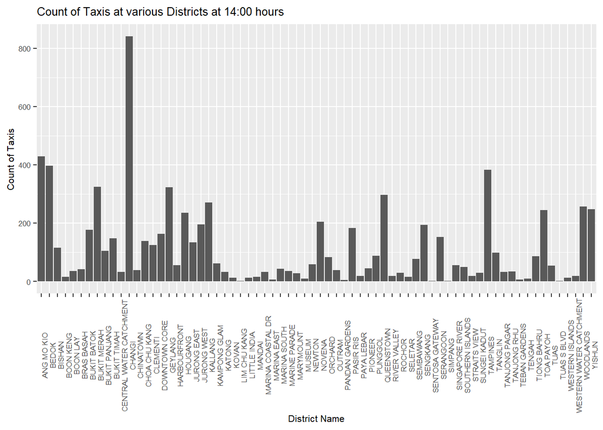

```r
ggplot(df) +   geom_bar(aes(x=District)) + theme(axis.text.x=element_text(angle=90)) + theme(text = element_text(size=8)) + labs(x="District Name", y="Count of Taxis", title="Count of Taxis at various Districts at 14:00 hours")
```

However, it seems quite tedious to read from this bar plot, given the number of categories.

We can visualize it as a formatted data table.

```r
df_counts <-  df%>%group_by(District) %>%count()%>%rename(Count_of_Taxis = n)

head(df_counts,10)
```

```
## # A tibble: 10 x 2
## # Groups:   District [10]
##    District      Count_of_Taxis
##    <chr>                  <int>
##  1 ANG MO KIO               429
##  2 BEDOK                    397
##  3 BISHAN                   115
##  4 BOON KENG                 15
##  5 BOON LAY                  36
##  6 BRAS BASAH                42
##  7 BUKIT BATOK              177
##  8 BUKIT MERAH              324
##  9 BUKIT PANJANG            104
## 10 BUKIT TIMAH              147
```

By using the formattable package, the visualization becomes much clearer.

We can easily spot the districts with high taxi availability at 14:00 hours. For instance, Changi district has the highest number of available taxis at that time. This is likely to be because airports in Singapore are located at Changi.

By looking at this data table, we can tell whether taxis will be available at 14:00 hours at our district for our upcoming trip, based on our district of interest.

For instance, if we are looking for a taxi at a district such as “LIM CHU KANG”, where there was only 1 taxi at 14:00 over the past 2 days, we should expect to find it difficult to find a taxi for our trip. We can then start to think of alternatives, such as pre-booking a taxi, since the chance of getting a taxi is quite low.

```r
formattable(df_counts,
            align = c("l",rep("r", NCOL(df_counts) - 1)),
            list(`Indicator Name` = formatter("span", style = ~ style(color = "grey", font.weight = "bold")),
                 `Count_of_Taxis` = color_bar("#FA614B")))
```

| District | Count_of_Taxis |
| --- | --- |
| ANG MO KIO | 429 |
| BEDOK | 397 |
| BISHAN | 115 |
| BOON KENG | 15 |
| BOON LAY | 36 |
| BRAS BASAH | 42 |
| BUKIT BATOK | 177 |
| BUKIT MERAH | 324 |
| BUKIT PANJANG | 104 |
| BUKIT TIMAH | 147 |
| CENTRAL WATER CATCHMENT | 32 |
| CHANGI | 841 |
| CHINATOWN | 39 |
| CHOA CHU KANG | 138 |
| CLEMENTI | 124 |
| DOWNTOWN CORE | 163 |
| GEYLANG | 323 |
| HARBOURFRONT | 55 |
| HOUGANG | 235 |
| JURONG EAST | 134 |
| JURONG WEST | 195 |
| KALLANG | 271 |
| KAMPONG GLAM | 61 |
| KATONG | 33 |
| KOVAN | 13 |
| LIM CHU KANG | 1 |
| LITTLE INDIA | 13 |
| MANDAI | 15 |
| MARINA COASTAL DR | 32 |
| MARINA EAST | 7 |
| MARINA SOUTH | 43 |
| MARINE PARADE | 36 |
| MARYMOUNT | 28 |
| MUSEUM | 10 |
| NEWTON | 58 |
| NOVENA | 205 |
| ORCHARD | 83 |
| OUTRAM | 38 |
| PANDAN GARDENS | 5 |
| PASIR RIS | 183 |
| PAYA LEBAR | 18 |
| PIONEER | 44 |
| PUNGGOL | 87 |
| QUEENSTOWN | 297 |
| RIVER VALLEY | 18 |
| ROCHOR | 30 |
| SELETAR | 16 |
| SEMBAWANG | 77 |
| SENGKANG | 194 |
| SENTOSA GATEWAY | 1 |
| SERANGOON | 152 |
| SIMPANG | 1 |
| SINGAPORE RIVER | 55 |
| SOUTHERN ISLANDS | 49 |
| STRAITS VIEW | 19 |
| SUNGEI KADUT | 30 |
| TAMPINES | 383 |
| TANGLIN | 98 |
| TANJONG PAGAR | 33 |
| TANJONG RHU | 34 |
| TEBAN GARDENS | 7 |
| TENGAH | 9 |
| TIONG BAHRU | 86 |
| TOA PAYOH | 245 |
| TUAS | 54 |
| TUAS S BLVD | 1 |
| WESTERN ISLANDS | 12 |
| WESTERN WATER CATCHMENT | 19 |
| WOODLANDS | 257 |
| YISHUN | 248 |

We can also visualise this taxi availability information on a leaflet map.

```r
values <- unique(df$District)
#print(values)

#Assign each district a value
assign_value <- function(x) {
  if (x %in% values) {
    index <- match(x,values)
    return(index)
  }


}

df_map <- df

df_map$Group <- sapply(df$District,assign_value)
head(df_map)
```

```
##         X1       X2   time       Date District Group
## 2 103.6208 1.265378 14: 00 2020-01-09     TUAS     1
## 3 103.6238 1.300970 14: 00 2020-01-09     TUAS     1
## 4 103.6256 1.306130 14: 00 2020-01-09     TUAS     1
## 5 103.6260 1.289620 14: 00 2020-01-09     TUAS     1
## 6 103.6264 1.289440 14: 00 2020-01-09     TUAS     1
## 7 103.6272 1.295100 14: 00 2020-01-09     TUAS     1
```

```r
#number of groups
k <- n_distinct(df_map$District)

#base map
map <- leaflet() %>% addProviderTiles(providers$CartoDB.Positron)

#loop through all groups and add layer 1 by 1
for (i in 1:k) {
  map <- map %>%addCircleMarkers(data = df_map %>% filter(Group == i), group = as.character(values[i]), lng = ~X1, lat = ~X2, radius = 10, popup = ~District, clusterOptions = markerClusterOptions())
  }

#create layer control
map %>% addLayersControl(overlayGroups = values,
      options = layersControlOptions(collapsed = FALSE)) %>%
    hideGroup(as.character(c(2:k)))
```

[interactive chart not shown]